# ASSIGNMENT NAME

| variable | factor | var_imp | var_imp_lower | var_imp_upper | p_value |
| --- | --- | --- | --- | --- | --- |
| NumSpaceHeroBadges | No | 1.28012 | 1.2016 | 1.35862 | 0.000 |
| TimesLostSpaceship | No | -0.91013 | -1.1440 | -0.67625 | 0.000 |
| NumFriendRequestIgnored | No | -0.80461 | -0.9764 | -0.63284 | 0.000 |
| GameLevel | No | 0.57684 | 0.4236 | 0.73004 | 0.000 |
| AcquiredSpaceship1 | Yes | 0.53822 | 0.3973 | 0.67912 | 0.000 |
| AcquiredIonWeapon1 | Yes | 0.47795 | 0.0798 | 0.87608 | 0.019 |
| NumGameDays | No | 0.46940 | 0.3175 | 0.62126 | 0.000 |
| NumAdsClicked | No | 0.39750 | 0.2890 | 0.50597 | 0.000 |
| TimesNavigator | No | -0.39284 | -0.6062 | -0.17946 | 0.000 |
| NumInGameMessagesSent | No | 0.31259 | 0.1579 | 0.46725 | 0.000 |

[output cut: 9 more lines]

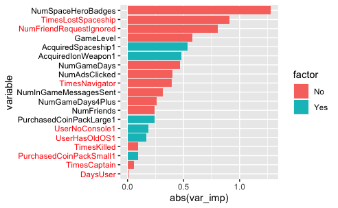

```r
varimp.logistic(lr) %>% plotimp.logistic()
```

The 5 most important features are - Number of space hero badges: the more badges the more likely to purchase - Times lost spaceship: more times a spaceship has been lost the less likely to purchase - Number of friend requests ignored: more friend requests ignored means less likely to purchase - Game level: the higher the level the more likely to purchase - Acquired spaceship: acquired spaceship means more likely to purchase

| model | auc |
| --- | --- |
| pred_lr_test | 0.803 |

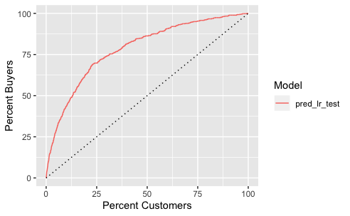

```r
pred_lr_test <- predict(lr, newdata=cg_organic_test, type="response")
gainsplot(pred_lr_test, label.var = cg_organic_test$converted)
```

## Part III

### Question 1

Calculate the response rate and profit of the control group not sent an ad

```r
revenuePerPurchase <- 14.99
costToServeAd <- 1.5

controlConvertVar <- (cg_organic_control %>% summarise(controlConvert = mean(converted)))$controlConvert
cat("Control response rate to Zalon: ", percent(controlConvertVar, .01))
```

```
Control response rate to Zalon:  5.69%
```

```r
profitControl <- nrow(cg_organic_control) * controlConvertVar* revenuePerPurchase
cat("\nProfit: ", dollar(profitControl, .01))
```

```
Profit:  $25,572.94
```

### Question 2

Calculate the response rate and profit of the randomly selected customers who were sent the ad

```r
cg_ad_random <- cg_ad_treatment[sample_random_30000,]

adConvertVar <- (cg_ad_random %>% summarise(adConvert = mean(converted)))$adConvert
cat("Ad treatment response rate to Zalon: ", percent(adConvertVar, .01))
```

```
Ad treatment response rate to Zalon:  13.04%
```

```r
profitAd <- nrow(cg_ad_random) * (adConvertVar* revenuePerPurchase - costToServeAd)
cat("\nProfit: ", dollar(profitAd, .01))
```

```
Profit:  $13,655.87
```

### Question 3

Calculate the response rate and profit of the customers from the remaining sample with the highest probability to buy according to the model

```r
cg_ad_scoring <- cg_ad_treatment[-sample_random_30000,]

cg_ad_scoring <- cg_ad_scoring %>% mutate(pred_lr = predict(lr, newdata=cg_ad_scoring, type="response"))

cg_ad_scoring <- cg_ad_scoring %>% arrange(desc(pred_lr))

cg_best <- head(cg_ad_scoring, 30000)
```

```r
bestConvertVar <- (cg_best %>% summarise(bestConvert = mean(converted)))$bestConvert
cat("Ad treatment response rate to Zalon: ", percent(bestConvertVar, .01))
```

```
Ad treatment response rate to Zalon:  21.51%
```

```r
profitBest <- nrow(cg_best) * (bestConvertVar* revenuePerPurchase - costToServeAd)
cat("\nProfit: ", dollar(profitBest, .01))
```

```
Profit:  $51,715.48
```

### Question 4

In summary:

Incremental profit from advertising using the model from no advertising is $26K, or double profits.

### Question 5

```r
cg_ad_scoring %>% arrange(pred_lr)
```

| converted | GameLevel | NumGameDays | NumGameDays4Plus | NumInGameMessagesSent | NumSpaceHeroBadges | NumFriendRequestIgnored | NumFriends | AcquiredSpaceship | AcquiredIonWeapon | TimesLostSpaceship | TimesKilled | TimesCaptain | TimesNavigator | PurchasedCoinPackSmall | PurchasedCoinPackLarge | NumAdsClicked | DaysUser | UserNoConsole | UserHasOldOS | pred_lr |
| --- | --- | --- | --- | --- | --- | --- | --- | --- | --- | --- | --- | --- | --- | --- | --- | --- | --- | --- | --- | --- |
| 1 | 9 | 16 | 0 | 211 | 0 | 79 | 73 | 0 | 0 | 3305 | 0 | 0 | 0 | 0 | 0 | 0 | 2070 | 0 | 0 | 0.000000000000000222 |
| 0 | 5 | 21 | 10 | 161 | 5 | 102 | 366 | 1 | 0 | 1 | 0 | 7 | 1092 | 0 | 0 | 6 | 3988 | 0 | 1 | 0.000000000002442546 |
| 0 | 8 | 14 | 0 | 429 | 0 | 73 | 1 | 0 | 0 | 484 | 0 | 0 | 0 | 0 | 0 | 0 | 2588 | 0 | 1 | 0.000000000106984909 |
| 0 | 10 | 19 | 0 | 278 | 0 | 116 | 246 | 1 | 0 | 494 | 0 | 4 | 0 | 0 | 0 | 17 | 1948 | 1 | 0 | 0.000000000181582911 |
| 0 | 8 | 12 | 0 | 70 | 0 | 27 | 30 | 0 | 0 | 368 | 0 | 0 | 0 | 1 | 0 | 12 | 2739 | 0 | 0 | 0.000000015911971985 |
| 0 | 6 | 13 | 8 | 2 | 1 | 4 | 122 | 1 | 0 | 0 | 0 | 34 | 670 | 0 | 0 | 7 | 1400 | 0 | 0 | 0.000000016810379425 |
| 1 | 5 | 15 | 0 | 285 | 11 | 66 | 109 | 0 | 0 | 477 | 0 | 0 | 0 | 0 | 0 | 13 | 2678 | 0 | 0 | 0.000000017973973330 |
| 0 | 10 | 21 | 0 | 42 | 0 | 85 | 0 | 0 | 0 | 317 | 0 | 0 | 0 | 0 | 0 | 11 | 3592 | 0 | 0 | 0.000000098872280904 |
| 0 | 1 | 8 | 4 | 0 | 0 | 0 | 0 | 1 | 0 | 0 | 0 | 9 | 426 | 1 | 0 | 1 | 2739 | 1 | 0 | 0.000000943618053707 |
| 0 | 9 | 4 | 0 | 149 | 4 | 108 | 233 | 1 | 0 | 298 | 0 | 0 | 0 | 1 | 0 | 8 | 1096 | 0 | 0 | 0.000001016050058731 |

[output cut: 990 more lines]

| model | auc |
| --- | --- |
| cg_ad_scoring$pred_lr | 0.644 |

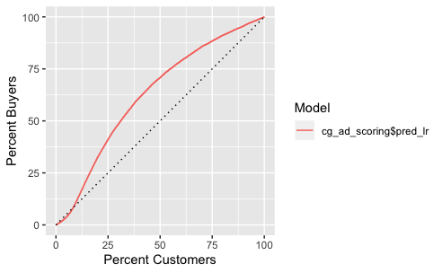

```r
gainsplot(cg_ad_scoring$pred_lr, label.var = cg_ad_scoring$converted)
```

### Question 6

What is the purpose of group 1 given that we already had data on organic conversions?

This enables us to eliminate any affects that timing might have on the advertisements. For instance, people may be more likely to buy gaming products during a week with bad weather, because more people are stuck at home inside.

## Part IV

### Question 1

```r
lr_retrain <- glm(fm , family = binomial, data = cg_ad_random)
summary(lr)
```

```
Call:
glm(formula = fm, family = binomial, data = cg_organic_train)

Deviance Residuals:
   Min      1Q  Median      3Q     Max
-2.332  -0.323  -0.246  -0.187   3.308

Coefficients:
                           Estimate  Std. Error z value             Pr(>|z|)
(Intercept)             -4.56976218  0.18349908  -24.90 < 0.0000000000000002
GameLevel                0.10359656  0.01403792    7.38    0.000000000000159
NumGameDays              0.03309250  0.00546256    6.06    0.000000001377779
NumGameDays4Plus         0.04086741  0.00879314    4.65    0.000003357468795
NumInGameMessagesSent    0.00147047  0.00037122    3.96    0.000074596755571
NumFriends               0.00129609  0.00030852    4.20    0.000026580817772
NumFriendRequestIgnored -0.01185530  0.00129129   -9.18 < 0.0000000000000002
NumSpaceHeroBadges       0.41777754  0.01307132   31.96 < 0.0000000000000002
AcquiredSpaceship1       0.53821523  0.07189386    7.49    0.000000000000071
AcquiredIonWeapon1       0.47795216  0.20312918    2.35              0.01863
TimesLostSpaceship      -0.03979973  0.00521815   -7.63    0.000000000000024
TimesKilled             -0.01583113  0.01683636   -0.94              0.34707
TimesCaptain            -0.00338417  0.00387684   -0.87              0.38271
TimesNavigator          -0.02364760  0.00655361   -3.61              0.00031
PurchasedCoinPackSmall1 -0.09242189  0.07024012   -1.32              0.18824
PurchasedCoinPackLarge1  0.23893905  0.07335258    3.26              0.00112
NumAdsClicked            0.02695746  0.00375303    7.18    0.000000000000683
DaysUser                -0.00000687  0.00005098   -0.13              0.89288
UserNoConsole1          -0.18519871  0.09146907   -2.02              0.04290
UserHasOldOS1           -0.16649116  0.12417135   -1.34              0.17998

(Intercept)             ***
GameLevel               ***
NumGameDays             ***
NumGameDays4Plus        ***
NumInGameMessagesSent   ***
NumFriends              ***
NumFriendRequestIgnored ***
NumSpaceHeroBadges      ***
AcquiredSpaceship1      ***
AcquiredIonWeapon1      *
TimesLostSpaceship      ***
TimesKilled
TimesCaptain
TimesNavigator          ***
PurchasedCoinPackSmall1
PurchasedCoinPackLarge1 **
NumAdsClicked           ***
DaysUser
UserNoConsole1          *
UserHasOldOS1
---
Signif. codes:  0 ‘***’ 0.001 ‘**’ 0.01 ‘*’ 0.05 ‘.’ 0.1 ‘ ’ 1

(Dispersion parameter for binomial family taken to be 1)

    Null deviance: 9120.7  on 20999  degrees of freedom
Residual deviance: 7438.1  on 20980  degrees of freedom
AIC: 7478

Number of Fisher Scoring iterations: 6
```

## Question 2

| model | auc |
| --- | --- |
| cg_ad_scoring$pred_lr | 0.703 |

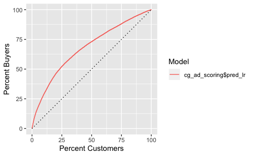

```r
cg_ad_scoring <- cg_ad_scoring %>% mutate(pred_lr = predict(lr_retrain, newdata=cg_ad_scoring, type="response"))

gainsplot(cg_ad_scoring$pred_lr, label.var = cg_ad_scoring$converted)
```

The AUC is higher, at 0.70 versus 0.64, here as customers from both the training data and the test data were show the advertisements.

### Question 3

```r
cg_ad_scoring <- cg_ad_scoring %>% arrange(desc(pred_lr))

cg_best <- head(cg_ad_scoring, 30000)

bestConvertVar <- (cg_best %>% summarise(bestConvert = mean(converted)))$bestConvert
cat("Ad treatment response rate to Zalon: ", percent(bestConvertVar, .01))
```

```
Ad treatment response rate to Zalon:  27.39%
```

```r
profitBest <- nrow(cg_best) * (bestConvertVar* revenuePerPurchase - costToServeAd)
cat("\nProfit: ", dollar(profitBest, .01))
```

```
Profit:  $78,172.83
```

### Question 4

| variable | factor | var_imp | var_imp_lower | var_imp_upper | p_value |
| --- | --- | --- | --- | --- | --- |
| NumSpaceHeroBadges | No | 1.28012 | 1.2016 | 1.35862 | 0.000 |
| TimesLostSpaceship | No | -0.91013 | -1.1440 | -0.67625 | 0.000 |
| NumFriendRequestIgnored | No | -0.80461 | -0.9764 | -0.63284 | 0.000 |
| GameLevel | No | 0.57684 | 0.4236 | 0.73004 | 0.000 |
| AcquiredSpaceship1 | Yes | 0.53822 | 0.3973 | 0.67912 | 0.000 |
| AcquiredIonWeapon1 | Yes | 0.47795 | 0.0798 | 0.87608 | 0.019 |
| NumGameDays | No | 0.46940 | 0.3175 | 0.62126 | 0.000 |
| NumAdsClicked | No | 0.39750 | 0.2890 | 0.50597 | 0.000 |
| TimesNavigator | No | -0.39284 | -0.6062 | -0.17946 | 0.000 |
| NumInGameMessagesSent | No | 0.31259 | 0.1579 | 0.46725 | 0.000 |

[output cut: 9 more lines]

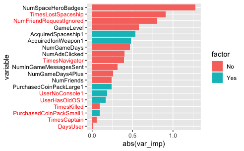

```r
varimp.logistic(lr) %>% plotimp.logistic()
```

| variable | factor | var_imp | var_imp_lower | var_imp_upper | p_value |
| --- | --- | --- | --- | --- | --- |
| NumAdsClicked | No | 1.21855 | 1.15829 | 1.2788 | 0.000 |
| NumFriends | No | 0.35897 | 0.29490 | 0.4230 | 0.000 |
| GameLevel | No | 0.29306 | 0.21155 | 0.3746 | 0.000 |
| NumGameDays | No | 0.21736 | 0.13472 | 0.3000 | 0.000 |
| UserHasOldOS1 | Yes | -0.20570 | -0.33913 | -0.0723 | 0.003 |
| TimesLostSpaceship | No | -0.16411 | -0.26661 | -0.0616 | 0.002 |
| PurchasedCoinPackLarge1 | Yes | 0.16203 | 0.08224 | 0.2418 | 0.000 |
| AcquiredIonWeapon1 | Yes | -0.12866 | -0.40022 | 0.1429 | 0.353 |
| NumSpaceHeroBadges | No | 0.09602 | 0.02630 | 0.1657 | 0.007 |
| TimesCaptain | No | 0.08958 | 0.03073 | 0.1484 | 0.003 |

[output cut: 9 more lines]

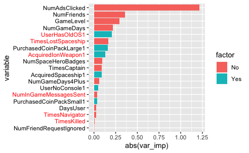

```r
varimp.logistic(lr_retrain) %>% plotimp.logistic()
```

When someone has seen an advertisement, the importance of factors is different from before they saw they the advertisement in predicting their likelihood to purchase. Number of ads clicked is now the most important factor (though this is likely to be misleading because many of these people would have purchased after clicking on the advertisement). THe next most important variable was number of friends. Gamve level was still important. Number of ggam days and whether the user has a new OS were also very important.

The organic model did not take into account the fact that these factors would change in importance, as no one in the training sample had seen an advertisement.

## Part IV

### Question 1

Train a neural network on the sample of customers who were exposed to the ad campaign

```r
set.seed(1234)
nn_cg <- nnet(fm, data=cg_ad_random, size=5, decay=0.1, maxit=1000)
```

```r
cg_ad_scoring <- cg_ad_scoring %>%
mutate(pred_nn = predict(nn_cg, newdata=cg_ad_scoring, type="raw")[,1])
```

### Question 2

Compare the performance of the neural network “ad” model and the logistic “ad” model from Part 4 on the “cg_ad_scoring” sample. Use gains curves and AUC to make the comparison. What do you find?

| model | auc |
| --- | --- |
| cg_ad_scoring$pred_nn | 0.778 |
| cg_ad_scoring$pred_lr | 0.703 |

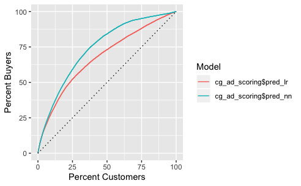

```r
gainsplot(cg_ad_scoring$pred_nn, cg_ad_scoring$pred_lr, label.var = cg_ad_scoring$converted)
```

The neural network has a higher AUC than the logistic regression, at 77.8% versus 70.3%. This means that the neural network performs better than the logistic regression.

```r
cg_ad_scoring <- cg_ad_scoring %>%
   arrange(-pred_nn)
cg_best_nn <-  cg_ad_scoring %>% slice(1:30000)

cg_ad_scoring <- cg_ad_scoring %>%
   arrange(-pred_lr)
cg_best_lr <-  cg_ad_scoring %>% slice(1:30000)
```

```r
nnConvertVar <- (cg_best_nn %>% summarise(nnConvert = mean(converted)))$nnConvert
cat("Neural network selection response rate to Zalon: ", percent(nnConvertVar, .01))
```

```
Neural network selection response rate to Zalon:  31.03%
```

```r
profitNn <- nrow(cg_best_nn) * (nnConvertVar* revenuePerPurchase - costToServeAd)
cat("\nProfit from Neural network selelection: ", dollar(profitNn, .01))
```

```
Profit from Neural network selelection:  $94,541.91
```

```r
cat("\n")
```

```r
lrConvertVar <- (cg_best_lr %>% summarise(lrConvert = mean(converted)))$lrConvert
cat("\nLogistic regression selection response rate to Zalon: ", percent(lrConvertVar, .01))
```

```
Logistic regression selection response rate to Zalon:  27.39%
```

```r
profitLr <- nrow(cg_best) * (bestConvertVar* revenuePerPurchase - costToServeAd)
cat("\nProfit from logistic regression selelection: ", dollar(profitLr, .01))
```

```
Profit from logistic regression selelection:  $78,172.83
```

```r
cat("\n")
```

```r
profitDif <- profitNn - profitLr
cat("\nProfit improvement from using neural network: ", dollar(profitDif, .01))
```

```
Profit improvement from using neural network:  $16,369.08
```

The profit uplift from using a neural network versus a logistic regression across 30,000 people is ~$16K